# Converged magnitudes in the paper

### Fig. S6 (mc_maps fig4)

`data/catalog_v4/mc_maps/fig4_regional_fmd.png`: 6.21% of pixels change from the control (stored magnitudes, today's scripts and inputs) to the converged figure (orange below). The control differs from the figure on main by 0.72% of pixels.

stored (main)

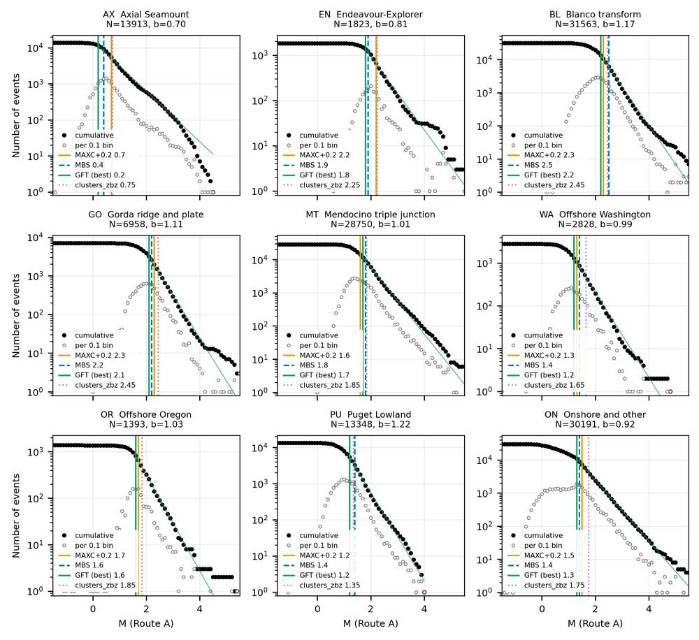

converged

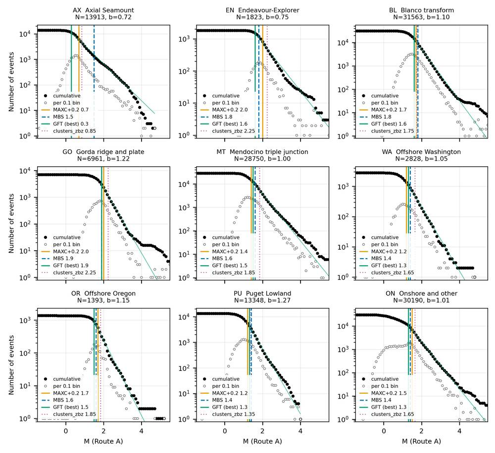

**changed pixels**

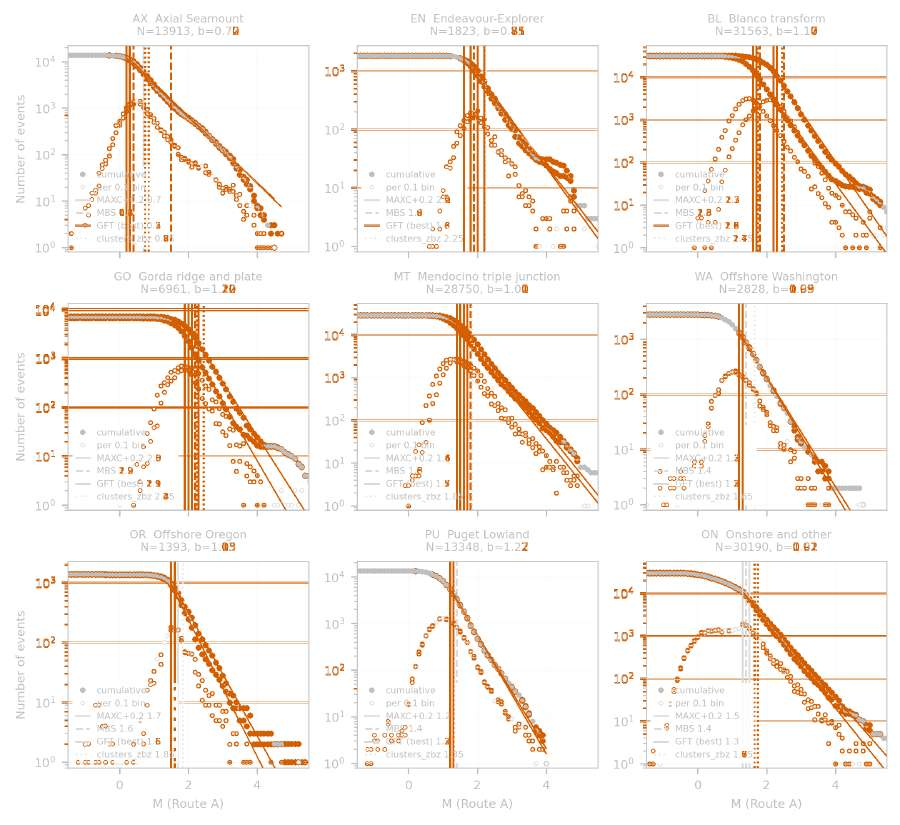

### Fig. S7 (mc_maps fig5)

`data/catalog_v4/mc_maps/fig5_qc_minus_all.png`: 11.31% of pixels change from the control (stored magnitudes, today's scripts and inputs) to the converged figure (orange below). The control differs from the figure on main by 0.36% of pixels.

stored (main)

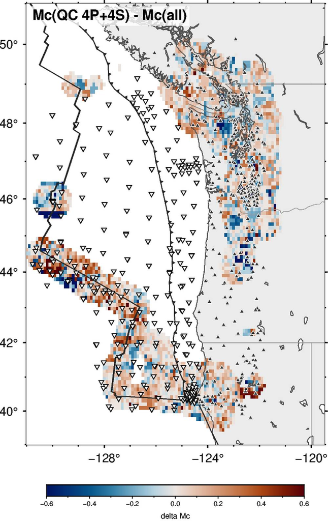

converged

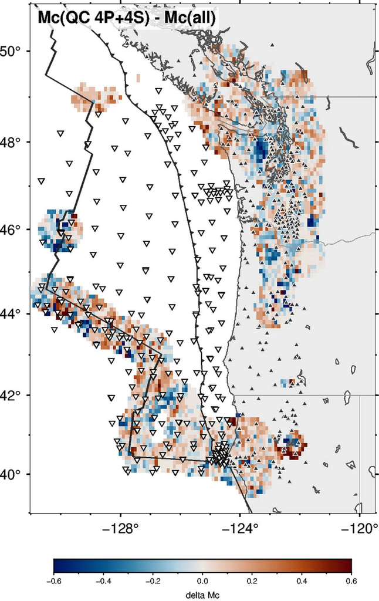

**changed pixels**

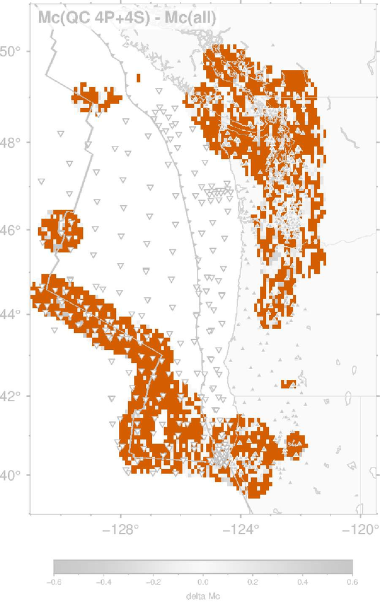

### Clustering report: fig_TR_density

`data/catalog_v4/clusters_zbz/fig_TR_density.png`: 7.67% of pixels change from the control (stored magnitudes, today's scripts and inputs) to the converged figure (orange below). The control differs from the figure on main by 1.36% of pixels.

stored (main)

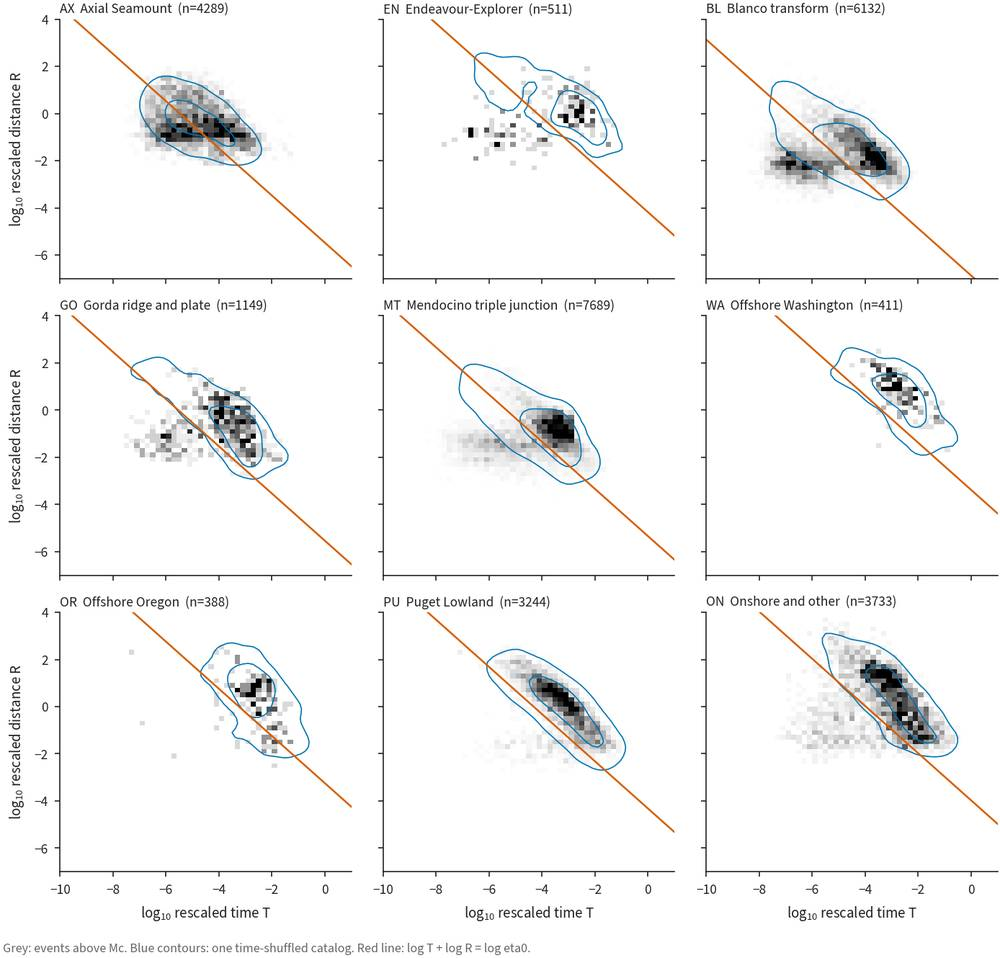

converged

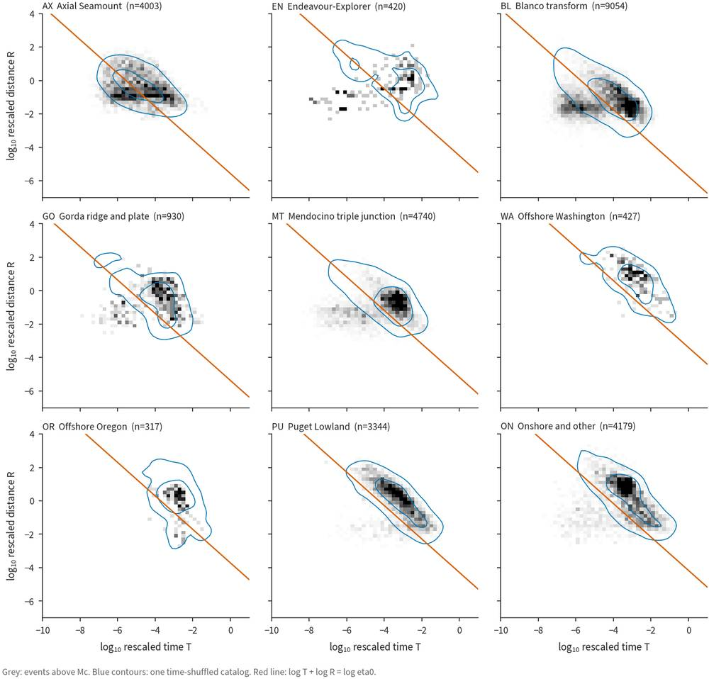

**changed pixels**

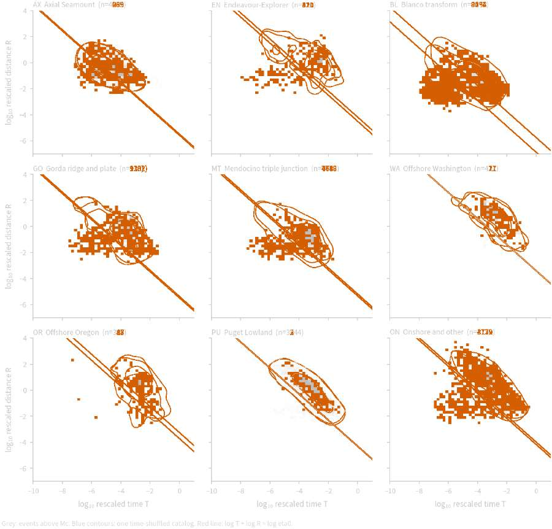

### Clustering report: fig_sensitivity

`data/catalog_v4/clusters_zbz/fig_sensitivity.png`: 4.78% of pixels change from the control (stored magnitudes, today's scripts and inputs) to the converged figure (orange below). The control differs from the figure on main by 0.40% of pixels.

stored (main)

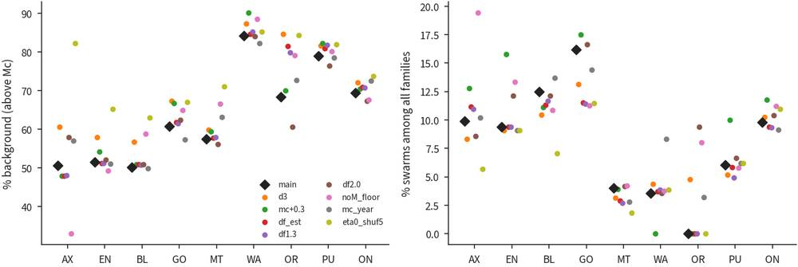

converged

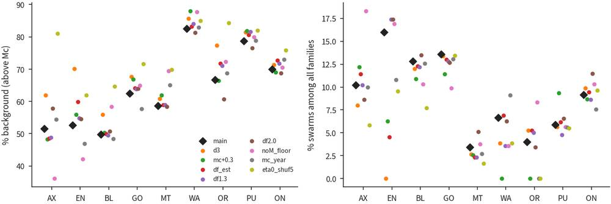

**changed pixels**

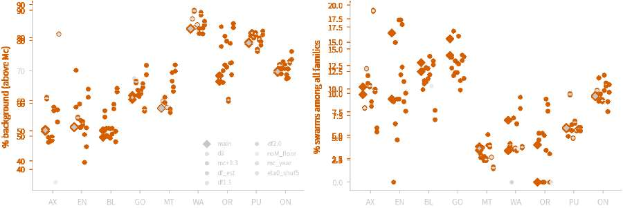

## Numbers, stored and converged

Recomputed from the products of the paper's scripts (stored products: main 5d6658bf; converged: this branch). 'text' is what the manuscript says now.

| where | item | text | stored | converged | how |
| --- | --- | --- | --- | --- | --- |
| Results 1; Text S5; Methods (tensors bullet) | events with a magnitude; types; matched moment tensors | 130,769 (Text S5: 130,767); 112 matched tensors | 130,769 with M (ML 130,651, Mw 83, Mw_cal 35); 147 matched tensors | 130,769 with M (ML 130,659, Mw 83, Mw_cal 27); 147 matched tensors | count of the Route A file; matched tensors = rows with Mw_mt minus the 3 v4.1 additions (ComCat Mw) |
| Results 1; Text S5; Methods | ComCat ML anchors: number, scatter (std), offset | 3,416 common events, scatter 0.21 | 3,416; 0.21 (stored run, as in the text; 12-thread legacy rerun 0.207); offset +0.413 | 3,416; 0.17; offset +0.356 | data/magnitude_converged/phase19_runs.csv (PR #45) |
| Results 1 (Fig. 2) | lowest node Mc: onshore (Mount St Helens) min; Axial min | 0.0-0.3 | ON -0.2, AX 0.2 | ON -0.2, AX 0.3 | mc_nodes_by_region.csv, period all |
| Results 1 (Fig. 2) | node medians Puget Lowland, offshore Washington | 1.0-1.1 | PU 1.1, WA 1.0 | PU 1.2, WA 1.1 | mc_nodes_by_region.csv |
| Results 1 (Fig. 2) | highest node Mc (western Blanco, northern Gorda) | 2.9-3.2 | max 3.2 at -129.5/43.7, -130.4/44.0, -129.4/43.7; BL max 3.2, GO max 2.8; nodes >= 2.9: 17 | max 2.8 at -129.3/43.8, -129.3/43.7, -129.4/43.6; BL max 2.8, GO max 2.4; nodes >= 2.9: 0 | mc_grid.csv (Mc_best) |
| Results 1 (Fig. 2); Table S6 | pooled Mc onshore and forearc (WA, PU, ON, OR, MT) | 1.2-1.7 | 1.2-1.7 (WA 1.2, PU 1.2, ON 1.3, OR 1.6, MT 1.7) | 1.3-1.5 (WA 1.3, PU 1.3, ON 1.3, OR 1.5, MT 1.5) | mc_regional.csv, variant all, period all, Mc_best |
| Results 1 (Fig. 2); Table S6 | pooled Mc offshore plate boundaries (EN, GO, BL) | 1.8-2.2 | 1.8-2.2 (EN 1.8, GO 2.1, BL 2.2) | 1.6-1.9 (EN 1.6, GO 1.9, BL 1.6) | mc_regional.csv |
| Results 1; Table S6 | pooled Mc all offshore (OFF) / whole catalog (ALL) | (not in the text) | OFF 2.2, ALL 2.1 | OFF 1.7, ALL 1.5 | mc_regional.csv |
| Results 1 (Fig. 2b) | offshore nodes with 150 events within 50 km (EN, GO, BL), by period | no offshore node in 2010 and 2016 | 2010: EN 0, GO 5, BL 0; 2016: EN 0, GO 0, BL 0; 2013-2015: EN 295, GO 648, BL 500 | 2010: EN 0, GO 5, BL 0; 2016: EN 0, GO 0, BL 0; 2013-2015: EN 295, GO 648, BL 500 | mc_nodes_by_region.csv count (node region as the clustering boxes) |
| Results 1 | rate of M >= 2.5 on the Blanco, 2010 and 2016, relative to 2013-2015 | 5% (2010), 8% (2016) | 5% (2010), 8% (2016); M >= 3.0: 20%, 19% | 28% (2010), 29% (2016); M >= 3.0: 39%, 47% | mc_regional.csv rr25 / rr30 (annual rate of the period over the 2013-2015 rate) |
| Results 1 | Mc 2011-2012 -> 2013-2015 (pooled), EN, BL, GO | improved by 0.2-0.4 (Blanco 2.6 to 2.2) | EN 1.9 -> 1.8; GO 2.1 -> 2.1; BL 2.6 -> 2.2 | EN 1.7 -> 1.6; GO 1.9 -> 1.9; BL 1.5 -> 1.6 | mc_regional.csv Mc_best by period |
| Results 1 | node medians 2011-2012 -> 2013-2015, EN, BL, GO | (README: EN 2.2 to 1.8, BL 2.3 to 2.1) | EN 2.2 -> 1.8; GO 2.1 -> 2.0; BL 2.3 -> 2.1 | EN 1.9 -> 1.8; GO 1.9 -> 1.8; BL 1.6 -> 1.5 | mc_nodes_by_region.csv by period |
| Results 1 | Mc change between periods where both have a node (mostly onshore) | median change 0.0 to 0.1 | 2010 -> 2013-2015 median -0.1 (1222 nodes); 2013-2015 -> 2016 +0.0 (661) | 2010 -> 2013-2015 median -0.1 (1222 nodes); 2013-2015 -> 2016 +0.0 (661) | median of the node difference |
| Results 1 | rate of M >= 2.5 near Mendocino (MT), 2016 relative to 2013-2015 | 10% | 10% | 11% | mc_regional.csv rr25 |
| Text S7 | which method is most conservative (nodes, whole period) | 84% of nodes; MBS 0.19 lower; best 0.14 lower | MAXC highest at 84% of nodes; MBS - MAXC -0.19; best - MAXC -0.14; GFT95 at 8%, GFT90 at 27%, MBS at 22% of nodes | MAXC highest at 83% of nodes; MBS - MAXC -0.19; best - MAXC -0.13; GFT95 at 8%, GFT90 at 27%, MBS at 22% of nodes | mc_grid.csv; 'highest' = MAXC >= best and >= MBS where MBS exists; means over nodes that have both values |
| Text S7 | QC-only minus all, Mc_best per node | median 0.0, IQR +-0.1 | median +0.0, IQR -0.1 to +0.1 (3,395 nodes) | median +0.0, IQR -0.1 to +0.1 (3,395 nodes) | mc_grid_qc.csv - mc_grid.csv |
| Text S7 | regions where the clustering Mc is below a map method (pooled region) | only Blanco MBS (2.5 against 2.45) | BL 2.45 < MBS 2.5; PU 1.35 < MBS 1.4 | AX 0.85 < MBS 1.5; BL 1.75 < MBS 1.8; PU 1.35 < MBS 1.4 | completeness_b_df.csv Mc against mc_regional.csv |
| Text S7 | Axial pooled: bootstrap sigma of Mc_best; MAXC; node Mc 10-90% | sigma 0.94; MAXC 0.7; nodes 0.4-1.0 | sigma 0.94; MAXC 0.7; GFT/best 0.2; nodes 0.4-1.0 | sigma 0.63; MAXC 0.7; GFT/best 0.3; nodes 0.4-1.2 | mc_regional.csv, mc_nodes_by_region.csv |
| Discussion Limits; Text S6 | events above the per-region Mc (analysis set) | 27,555 | 27,555 | 27,423 | regions_zbz.csv n_analysis |
| Text S6; Table S5 | clustering Mc range and per region | 0.75-2.45 | 0.75-2.45 (AX 0.75, EN 2.25, BL 2.45, GO 2.45, MT 1.85, WA 1.65, OR 1.85, PU 1.35, ON 1.75) | 0.85-2.25 (AX 0.85, EN 2.25, BL 1.75, GO 2.25, MT 1.85, WA 1.65, OR 1.85, PU 1.35, ON 1.65) | regions_zbz.csv Mc (MAXC + 0.2, largest yearly value) |
| Text S6 | measured epicentral correlation dimension D2 (df_est) range | 0.8-1.4 | 0.8-1.4 | 0.8-1.4 | completeness_b_df.csv |
| Results (clustering) | background share, ridges and transforms (AX, BL, GO) | about half | AX 50.6%, BL 50.2%, GO 60.8% | AX 51.6%, BL 49.8%, GO 62.5% | regions_zbz.csv |
| Results (clustering); Discussion | swarms among families of >= 5 events (AX, BL, GO) | two thirds | AX 60.6% of 66, BL 66.0% of 94, GO 65.4% of 26 | AX 60.7% of 61, BL 62.8% of 145, GO 55.0% of 20 | setting_stats.csv |
| Results (clustering) | Mendocino triple junction: swarm share of families >= 5; events Mc+1..2 with no aftershock | 31%; 76% | 30.6% of 49; 75.7% of 592 | 27.6% of 29; 73.6% of 417 | setting_stats.csv |
| Results (clustering) | background share, forearc, Puget and onshore (WA, OR, PU, ON) | 68-84% | 68-84% (WA 84.2, OR 68.4, PU 79.0, ON 69.4) | 67-82% (WA 82.5, OR 66.7, PU 78.7, ON 70.0) | regions_zbz.csv |
| Results (clustering) | Blanco swarms: duration and extent | median 4 hours, 4 km | 62 swarms; median duration (90%) 4.0 h; median extent 3.9 km | 91 swarms; median duration (90%) 4.0 h; median extent 4.6 km | families_zbz.csv, region BL, type swarm |
| Results (clustering); Discussion | swarm share on the West Blanco, Surveyor and Cascadia Depression strands | 33-45% | 33-45% (BL004a 45.0, BL015a 34.5, BL006a 34.6, BL012 32.9) | 28-45% (BL004a 44.8, BL015a 42.2, BL006a 28.1, BL012 27.8) | faults_v0_cluster_counts.csv pct_swarm (% of events above Mc on the strand); the four strands of the stored 33-45% |
| Results (clustering) | check: the five Blanco strands with the highest swarm share (>= 30 events above Mc) | nan | BL004a 45.0; BL006a 34.6; BL015a 34.5; BL012 32.9; BL018a 30.2 | BL004a 44.8; BL015a 42.2; BL018a 28.3; BL006a 28.1; BL012 27.8 | faults_v0_cluster_counts.csv |
| Results (clustering); Text S6 | six large earthquakes: family type, role of the large event, share of events before the largest | all mainshock-aftershock, mainshock first | 2010-01-10 mainshock-aftershock (mainshock, 0% before); 2014-03-10 mainshock-aftershock (mainshock, 0% before); 2011-09-09 mainshock-aftershock (mainshock, 0% before); 2014-04-24 mainshock-aftershock … | 2010-01-10 mainshock-aftershock (mainshock, 0% before); 2014-03-10 mainshock-aftershock (mainshock, 0% before); 2011-09-09 mainshock-aftershock (mainshock, 0% before); 2014-04-24 mainshock-aftershock … | validation_sequences.csv + families_zbz.csv |
| Results (clustering); Text S6 | 2015 Axial eruption family | one 632-event swarm | family 1758: swarm, 632 events above Mc (805 with the events below Mc) | family 1750: swarm, 601 events above Mc (762 with the events below Mc) | validation_sequences.csv |
| Results (short-lived), Fig. 6A | Axial events above Mc per week; swarm families per month | about 60 (Nov 2014) -> about 300 (mid-Mar 2015); 1 -> 16 (Mar) and 13 (Apr) swarms; eruption week 1,021; below 15 per week within four weeks; almost none above Mc 0.75 | 7-day bins: Nov 2014 17-59 (mean 39), mid-Mar 2015 mean 314 (max 339); eruption week 1,024 (calendar week Mon-Sun, week of 26 Apr) or 999 (7-day bin of Fig. 6A); next 7-day bins [45, 11, 4, 2, 0]; swa… | 7-day bins: Nov 2014 16-54 (mean 36), mid-Mar 2015 mean 285 (max 310); eruption week 998 (calendar week Mon-Sun, week of 26 Apr) or 975 (7-day bin of Fig. 6A); next 7-day bins [41, 5, 4, 1, 0]; swarm … | events_zbz.csv.gz in_analysis, region AX; families_zbz.csv swarms by start month |
| Results (short-lived) | Axial clustering Mc | Mc 0.75 | 0.75 | 0.85 | regions_zbz.csv |
| Results (short-lived), Fig. 6B | West Blanco swarm of 1 June 2015 | 23 km in 6 h, 41 km in 1 day, the length the family kept for the next 64 days (755 events) | family 1803: 755 events (77 above Mc), 64 days (01 Jun to 04 Aug 2015); along-strike extent (5-95%): 6 h 23 km, 1 day 41 km, whole family 43 km, after day 1 42 km; Fig. 6B: 501 events in 12 days, M 0.… | family 1797: 850 events (277 above Mc), 100 days (01 Jun to 09 Sep 2015); along-strike extent (5-95%): 6 h 23 km, 1 day 41 km, whole family 46 km, after day 1 49 km; Fig. 6B: 503 events in 12 days, M … | largest BL family starting in June 2015 (as Fig. 6B); distance along 111 deg as Fig. 6B, 5-95% range of all family events (reproduces the text's 23 and 41 km) |
| Results (short-lived), Fig. 6D | western Mendocino transform: events away from the coast with and without OBS | only events near the coast or above M 4 remain | QC events west of 125.5W: 1,486 in weeks with an OBS within 120 km, 58 without (56 in 2012-2015, M 1.7-3.4; 2016: M 4.7, M 6.6) | QC events west of 125.5W: 1,486 in weeks with an OBS within 120 km, 58 without (56 in 2012-2015, M 1.5-3.2; 2016: M 4.7, M 6.6) | QC events of Fig. 6D; weeks shaded as in Fig. 6D (an ocean-bottom station within 120 km of 40.45N 126.2W) |
| Text S6 | bimodality (Ashman D): real; shuffled (mean of 3 shuffles) | 1.6-3.4 to 0.3-1.6 | 1.6-3.4; 0.3-1.6 | 1.7-2.9; 0.4-1.3 | regions_zbz.csv, shuffle_test.csv |
| Text S6 | shuffled events that pass the real threshold (mean of 3 shuffles; regions except Axial) | 3-17% (34% at Axial) | linked below the real threshold: 3-17% (AX 34%); below eta0 without the cap: 8-26% (AX 36%) | linked below the real threshold: 3-19% (AX 33%); below eta0 without the cap: 10-26% (AX 35%) | shuffle_test.csv frac_linked (threshold and distance cap) and frac_below_eta0 |
| Text S6 | sensitivity: label agreement under the variants; conservative threshold | 84-99%; +1 to +32 points | 84-100% keep the label (d3 84-97, df1.3 88-99, df2.0 92-100, df_est 87-100, mc+0.3 88-96, mc_year 93-100); conservative threshold: background +1 to +32 points | 83-99% keep the label (d3 83-97, df1.3 96-98, df2.0 93-99, df_est 93-99, mc+0.3 89-95, mc_year 92-99); conservative threshold: background +2 to +29 points | sensitivity_zbz.csv (agree_bg_vs_clustered_with_main; eta0_shuf5 minus main pct_background) |
| Table S4 (fault_surfaces_v0_literature.csv) | largest Route A M on GO004 and GO011 | GO004 'catalog maximum M5.6 on 2015-04-24'; GO011 'catalog maximum M4.1 on 2014-10-03' (catalog magnitude column) | GO004 Mw 5.45 (event 144373, 2015-04-24); GO011 ML 3.85 (event 103612, 2014-10-03) | GO004 Mw 5.45 (event 144373, 2015-04-24); GO011 ML 3.67 (event 103612, 2014-10-03) | fault_surfaces_v0_members.csv joined with the Route A file |

### Table S6 (mc_regional.csv), Mc_best by region, whole period

| region | n stored | n conv. | mc_maxc stored | mc_maxc conv. | mc_mbs stored | mc_mbs conv. | mc_gft90 stored | mc_gft90 conv. | mc_gft95 stored | mc_gft95 conv. | mc_best stored | mc_best conv. | b stored | b conv. | sigma_boot stored | sigma_boot conv. |
| --- | --- | --- | --- | --- | --- | --- | --- | --- | --- | --- | --- | --- | --- | --- | --- | --- |
| AX | 13913.00 | 13913.00 | 0.70 | 0.70 | 0.40 | 1.50 | 0.20 | 0.30 | nan | nan | 0.20 | 0.30 | 0.70 | 0.72 | 0.94 | 0.63 |
| EN | 1823.00 | 1823.00 | 2.20 | 2.00 | 1.90 | 1.80 | 1.80 | 1.60 | nan | nan | 1.80 | 1.60 | 0.81 | 0.75 | 0.05 | 0.09 |
| BL | 31563.00 | 31563.00 | 2.30 | 1.70 | 2.50 | 1.80 | 2.00 | 1.40 | 2.20 | 1.60 | 2.20 | 1.60 | 1.17 | 1.10 | 0.03 | 0.02 |
| GO | 6958.00 | 6961.00 | 2.30 | 2.00 | 2.20 | 1.90 | 1.90 | 1.70 | 2.10 | 1.90 | 2.10 | 1.90 | 1.11 | 1.22 | 0.02 | 0.08 |
| MT | 28750.00 | 28750.00 | 1.60 | 1.40 | 1.80 | 1.60 | 1.40 | 1.20 | 1.70 | 1.50 | 1.70 | 1.50 | 1.01 | 1.00 | 0.17 | 0.17 |
| WA | 2828.00 | 2828.00 | 1.30 | 1.20 | 1.40 | 1.40 | 1.00 | 1.00 | 1.20 | 1.30 | 1.20 | 1.30 | 0.99 | 1.05 | 0.09 | 0.09 |
| OR | 1393.00 | 1393.00 | 1.70 | 1.70 | 1.60 | 1.60 | 1.40 | 1.50 | 1.60 | nan | 1.60 | 1.50 | 1.03 | 1.15 | 0.08 | 0.11 |
| PU | 13348.00 | 13348.00 | 1.20 | 1.20 | 1.40 | 1.40 | 1.00 | 1.00 | 1.20 | 1.30 | 1.20 | 1.30 | 1.22 | 1.27 | 0.16 | 0.17 |
| ON | 30191.00 | 30190.00 | 1.50 | 1.50 | 1.40 | 1.40 | 1.10 | 1.20 | 1.30 | 1.30 | 1.30 | 1.30 | 0.92 | 1.01 | 0.00 | 0.00 |
| OFF | 44565.00 | 44568.00 | 2.30 | 1.70 | 2.40 | 1.90 | 2.00 | 1.50 | 2.20 | 1.70 | 2.20 | 1.70 | 1.15 | 1.09 | 0.01 | 0.02 |
| ALL | 130767.00 | 130769.00 | 1.60 | 1.50 | 2.30 | 1.70 | 1.90 | 1.30 | 2.10 | 1.50 | 2.10 | 1.50 | 1.05 | 1.00 | 0.02 | 0.00 |

### Table S5 (regions_zbz.csv)

| region | n_analysis stored | n_analysis conv. | Mc stored | Mc conv. | b stored | b conv. | log_eta0 stored | log_eta0 conv. | ashman_D stored | ashman_D conv. | pct_background stored | pct_background conv. | pct_MA stored | pct_MA conv. | pct_swarm stored | pct_swarm conv. | pct_multiplet stored | pct_multiplet conv. | n_families stored | n_families conv. | n_swarm stored | n_swarm conv. |
| --- | --- | --- | --- | --- | --- | --- | --- | --- | --- | --- | --- | --- | --- | --- | --- | --- | --- | --- | --- | --- | --- | --- |
| AX | 4290 | 4004 | 0.75 | 0.85 | 0.77 | 0.77 | -5.47 | -5.56 | 2.27 | 2.32 | 50.6 | 51.6 | 15.1 | 14.2 | 25.4 | 25.5 | 8.9 | 8.7 | 404 | 362 | 40 | 37 |
| EN | 512 | 421 | 2.25 | 2.25 | 0.84 | 0.84 | -4.18 | -4.5 | 3.42 | 2.86 | 51.6 | 52.7 | 37.1 | 33.5 | 6.1 | 7.4 | 5.3 | 6.4 | 32 | 25 | 3 | 4 |
| BL | 6133 | 9055 | 2.45 | 1.75 | 1.27 | 1.17 | -6.86 | -5.74 | 3.41 | 2.93 | 50.2 | 49.8 | 17.6 | 18.6 | 22.4 | 22.5 | 9.8 | 9.2 | 497 | 711 | 62 | 91 |
| GO | 1150 | 931 | 2.45 | 2.25 | 1.17 | 1.16 | -5.54 | -5.36 | 2.82 | 2.78 | 60.8 | 62.5 | 16.7 | 18.7 | 14.3 | 11.4 | 8.3 | 7.4 | 105 | 81 | 17 | 11 |
| MT | 7690 | 4741 | 1.85 | 1.85 | 1.06 | 1.03 | -5.34 | -5.18 | 2.46 | 2.56 | 57.5 | 58.6 | 37.3 | 37 | 1.5 | 1.1 | 3.8 | 3.2 | 373 | 233 | 15 | 8 |
| WA | 412 | 428 | 1.65 | 1.65 | 1.09 | 1.14 | -3.38 | -3.4 | 1.84 | 1.72 | 84.2 | 82.5 | 8.7 | 9.1 | 1.5 | 2.8 | 5.6 | 5.6 | 28 | 30 | 1 | 2 |
| OR | 389 | 318 | 1.85 | 1.85 | 1.01 | 1.22 | -3.25 | -3.71 | 1.62 | 1.74 | 68.4 | 66.7 | 21.9 | 22 | 0 | 1.9 | 9.8 | 9.4 | 31 | 25 | 0 | 1 |
| PU | 3245 | 3345 | 1.35 | 1.35 | 1.33 | 1.32 | -4.32 | -4.29 | 1.78 | 1.79 | 79 | 78.7 | 11.1 | 11.3 | 4.2 | 4.2 | 5.8 | 5.8 | 198 | 204 | 12 | 12 |
| ON | 3734 | 4180 | 1.75 | 1.65 | 0.93 | 1.04 | -3.97 | -4.17 | 2.13 | 1.86 | 69.4 | 70 | 14.6 | 14.7 | 7.7 | 7.1 | 8.3 | 8.3 | 276 | 295 | 27 | 27 |